# Review template

Yann

10/01/22

# Data cleaning checks

version 1.1.0.

This review is separated into two parts *Data checks* and *Cleaning log*:  
- The first part will performed different check on the dataset, depending on the information available (time, outliers, shortest path, etc.).  
- The second part will look at how the cleaning was performed. It will first look if the values from the cleaning log are correctly changed in the clean data, and then it will look at differences between the raw data and clean data and see if anything was not logged into the cleaning log.

The summary can be found in the output folder.

```r
library(tidyverse)
library(knitr)
library(kableExtra)
# library(cleaninginspectoR) #devtools::install_github("impact-initiatives/cleaninginspectoR")
source("utils/rendering.R")
source("utils/check_cleaning.R")
```

```r
#the only section that should be changed.
raww <- readxl::read_excel("inputs/REACH_UKR2008_Dataset Raw non PII HERAIII_NOV2021.xlsx", guess = 10000)
cleann <- readxl::read_excel("inputs/REACH_UKR2008_Dataset clean HERAIII_NOV2021.xlsx", guess = 50000)
logg <- readxl::read_excel("inputs/REACH_UKR2008_Data cleaning log HERAIII_DEC2021.xlsx", guess = 50000,
                           sheet = "VCL")
dell <- readxl::read_excel("inputs/REACH_UKR2008_Data cleaning log HERAIII_DEC2021.xlsx", guess = 50000,
                           sheet = "GCL")

questions <- readxl::read_excel("inputs/REACH_UKR2008_Questionnaire HERAIII_NOV2021.xlsx")
choices <- readxl::read_excel("inputs/REACH_UKR2008_Questionnaire HERAIII_NOV2021.xlsx", sheet = 2)

uuid_raww <- "_uuid"
uuid_cleann <- "_uuid"
uuid_logg <- "uuid"
uuid_dell <- "uuid"

#names from the cleaning log
var_logg <- "question.name"
old_value_logg <- "old.value"
new_value_logg <- "new.value"

#tests to include  TRUE / FALSE
check_for_duplicates <- TRUE
check_for_pii <- TRUE
check_for_time <- TRUE
check_for_shortest_path <- TRUE
check_for_outliers <- TRUE
check_for_logical <- TRUE
check_for_others <- TRUE
check_for_deletions <- TRUE
check_for_etc <- TRUE
check_for_cleaning_log <- TRUE
check_for_raw_clean_data <- TRUE
```

```r
#create a binding key for the cleaning log
logg <- logg %>%
  mutate(binding = paste0(!!sym(uuid_logg), "-/-", !!sym(var_logg)))
list_log <- list()
```

## 1. Data checks

### Checks for duplicates

```r
if (check_for_duplicates) {
  duplicate_log <- cleaninginspectoR::find_duplicates(cleann, uuid_cleann) %>%
    mutate(uuid = cleann[[uuid_cleann]][index])

  list_log$duplicate_log <- duplicate_log

  print_log(duplicate_log, "No duplicates found")

}
```

```
## No duplicates found
```

### Checks for PII

```r
if (check_for_pii) {
  pii_log <- cleaninginspectoR::sensitive_columns(cleann)

  list_log$pii_log <- pii_log

  print_log(pii_log, "No sensitive columns found")
}
```

| index | value | variable | has_issue | issue_type |
| --- | --- | --- | --- | --- |
| NA | NA | a7_phone | TRUE | Potentially sensitive information. Please ensure all PII is removed |
| NA | NA | a13_6_wrong_contact_phone | TRUE | Potentially sensitive information. Please ensure all PII is removed |
| NA | NA | a19_3_another_hh_member_phone | TRUE | Potentially sensitive information. Please ensure all PII is removed |

*NOTE*:  
- Only looks for the words “GPS, gps, phone, Latitude, Longitude, Phone” in the names of the dataset.  
- It does not check the value in those columns

### Check for time

```r
lower_treshold <- 15
higher_threshold <- 100

if (check_for_time) {
  time_log <- cleaninginspectoR::check_time(cleann, duration_threshold_lower = lower_treshold,
                                          duration_threshold_upper = higher_threshold)

  list_log$time_log <- time_log

  print_log(time_log, "No time sensitive interviews found")

}
```

```
## No time sensitive interviews found
```

**Note**:  
- Check time for lower threshold as 15 minutes and higher threshold as 100 minutes.

### Check for shortest path

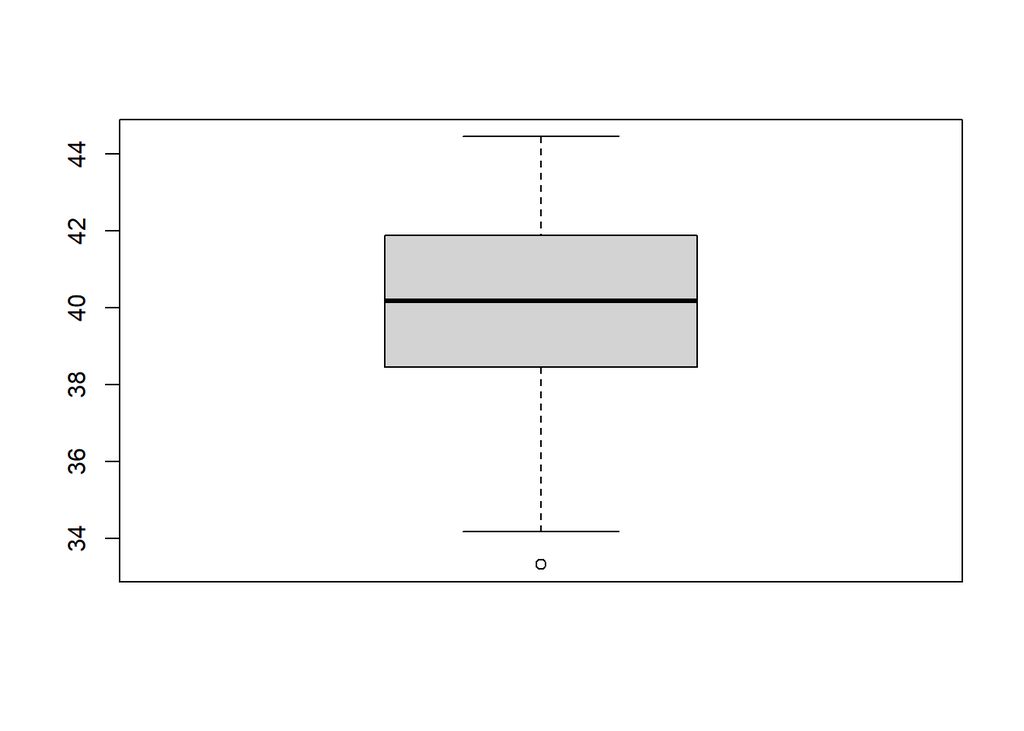

```r
# take only select and integer to look at NA (removing text, dummies, notes, etc.)
if (check_for_shortest_path) {
  if (exists("questions")) {
    names_for_blanks_check <- questions %>%
      filter(grepl("select", type) | type == "integer") %>%
      pull(name)

    cleann$blanks <- cleann %>%
      select(any_of(names_for_blanks_check)) %>%
      check_blanks()

  } else {
    cleann$blanks <- cleann %>%
      check_blanks()
  }

  cleann$blanks %>% boxplot()
}
```

**NOTE**:  
- This plot shows how many NA the interviews have. You should check values with lots of blanks. As there is not a specific threshold, but you should check interviews for high percentage of blanks. *Dataset with the **blank** column is in the output folder.*

### Check for outliers

```r
if (check_for_outliers) {
  outlier_log <- cleaninginspectoR::find_outliers(cleann) %>%
    mutate(uuid = cleann[[uuid_cleann]][index])

  list_log$outlier_log <- outlier_log

  print_log(outlier_log, "No outlier found")

}
```

| index | value | variable | has_issue | issue_type | uuid |
| --- | --- | --- | --- | --- | --- |
| 57 | 200.00000 | e3_1_income_amount_loop_paid_work_employment | TRUE | log normal distribution outlier | 7ca2348a-7330-4dad-b8b9-ca01bf031c69 |
| 84 | 400.00000 | e3_1_income_amount_loop_paid_work_employment | TRUE | log normal distribution outlier | 9f3d21c1-7e78-4328-b3ab-54e1c959649d |
| 555 | 600.00000 | e3_1_income_amount_loop_paid_work_employment | TRUE | log normal distribution outlier | fcee1ba4-12cf-4b2c-9664-ebe87c99c9a6 |
| 695 | 280.00000 | e3_1_income_amount_loop_paid_work_employment | TRUE | log normal distribution outlier | 073b36c2-957c-4a47-8586-155c6630c992 |
| 813 | 500.00000 | e3_1_income_amount_loop_paid_work_employment | TRUE | log normal distribution outlier | 846f5fd4-5c29-4238-9141-d3e0b28f2e7e |
| 853 | 400.00000 | e3_1_income_amount_loop_paid_work_employment | TRUE | log normal distribution outlier | 45106c52-aee2-45e4-aa7f-67090fa55748 |
| 1014 | 300.00000 | e3_1_income_amount_loop_paid_work_employment | TRUE | log normal distribution outlier | 3c11483f-67e0-418d-b8e8-82a3ff5c3f3c |
| 1138 | 300.00000 | e3_1_income_amount_loop_paid_work_employment | TRUE | log normal distribution outlier | 61841b11-58ac-4c12-a57e-5329456dcdeb |
| 570 | 56000.00000 | e4_1_income_amount_loop_self_employed_from_own_business | TRUE | normal distribution outlier | 140a3d33-4311-418a-af8b-d823c7982d32 |
| 916 | 20000.00000 | e5_1_income_amount_loop_pension | TRUE | log normal distribution outlier | ecac0620-e2ea-4a23-908b-73a1e1f85dfb |
| 695 | 120000.00000 | e8_1_income_amount_loop_loans_borrowing_money | TRUE | log normal distribution outlier | 073b36c2-957c-4a47-8586-155c6630c992 |
| 14 | 76000.00000 | e13_21_sum_of_incomes_calc | TRUE | log normal distribution outlier | e34aa64b-629f-4694-a10c-67ccbe180e41 |
| 406 | 500.00000 | e13_21_sum_of_incomes_calc | TRUE | log normal distribution outlier | 412d4e25-3082-4859-bd30-c93ae37bb5a8 |
| 695 | 124180.00000 | e13_21_sum_of_incomes_calc | TRUE | log normal distribution outlier | 073b36c2-957c-4a47-8586-155c6630c992 |
| 813 | 800.00000 | e13_21_sum_of_incomes_calc | TRUE | log normal distribution outlier | 846f5fd4-5c29-4238-9141-d3e0b28f2e7e |
| 153 | 200.00000 | g2_spent_food | TRUE | log normal distribution outlier | cfbf5eb7-84a5-44b7-aa96-10053c64a77e |
| 406 | 100.00000 | g2_spent_food | TRUE | log normal distribution outlier | 412d4e25-3082-4859-bd30-c93ae37bb5a8 |
| 586 | 200.00000 | g2_spent_food | TRUE | log normal distribution outlier | 661b6242-13e3-4cdb-a1df-280b40467e24 |
| 813 | 250.00000 | g2_spent_food | TRUE | log normal distribution outlier | 846f5fd4-5c29-4238-9141-d3e0b28f2e7e |
| 951 | 200.00000 | g2_spent_food | TRUE | log normal distribution outlier | 294804a5-2133-4760-afbc-f20ef3802354 |
| 1124 | 200.00000 | g2_spent_food | TRUE | log normal distribution outlier | 1f2b2d92-31ce-41db-bc9a-b73e41b77469 |
| 14 | 40000.00000 | g5_spent_healthcare | TRUE | log normal distribution outlier | e34aa64b-629f-4694-a10c-67ccbe180e41 |
| 571 | 47000.00000 | g5_spent_healthcare | TRUE | log normal distribution outlier | eeb826b0-c579-428b-8d21-94eac335bffe |
| 581 | 30000.00000 | g5_spent_healthcare | TRUE | log normal distribution outlier | 886568c4-5b5a-4c7c-b1ae-44aac144fd64 |
| 695 | 120000.00000 | g5_spent_healthcare | TRUE | log normal distribution outlier | 073b36c2-957c-4a47-8586-155c6630c992 |
| 999 | 30000.00000 | g5_spent_healthcare | TRUE | log normal distribution outlier | 9ff20924-aaa8-4d2d-9efd-02759c085681 |
| 1052 | 30000.00000 | g5_spent_healthcare | TRUE | log normal distribution outlier | eb3cd531-30a0-4c44-8d69-22c354a25649 |
| 1158 | 49000.00000 | g5_spent_healthcare | TRUE | log normal distribution outlier | 9543cd8f-e3c3-42a3-967c-094eeec924a9 |
| 77 | 15.00000 | g7_spent_transportation | TRUE | log normal distribution outlier | 3b4e38ae-084c-4a65-a6a9-88b5c8110823 |
| 403 | 13.00000 | g7_spent_transportation | TRUE | log normal distribution outlier | 2b7724dc-5e12-4ae7-b010-a64db2d5ac03 |
| 570 | 34000.00000 | g7_spent_transportation | TRUE | log normal distribution outlier | 140a3d33-4311-418a-af8b-d823c7982d32 |
| 867 | 10.00000 | g7_spent_transportation | TRUE | log normal distribution outlier | 8ed6b43b-8d35-40fa-89d1-ba9d45789fc9 |
| 37 | 5000.00000 | g10_spent_hygiene | TRUE | log normal distribution outlier | 5ffd8f7e-1d2e-4251-835e-b8d709944f03 |
| 69 | 5000.00000 | g10_spent_hygiene | TRUE | log normal distribution outlier | 89662917-7491-433e-b06a-8934c35ccff4 |
| 278 | 20.00000 | g10_spent_hygiene | TRUE | log normal distribution outlier | dda0cb56-ab8b-4306-8a82-46ef5a0589b4 |
| 557 | 20.00000 | g10_spent_hygiene | TRUE | log normal distribution outlier | 3bd401be-fb3f-466d-a3b2-8b3bb95f68bf |
| 695 | 10.00000 | g10_spent_hygiene | TRUE | log normal distribution outlier | 073b36c2-957c-4a47-8586-155c6630c992 |
| 854 | 5000.00000 | g10_spent_hygiene | TRUE | log normal distribution outlier | f0a787c3-2f7d-4750-902a-eb231992cfd2 |
| 909 | 20.00000 | g10_spent_hygiene | TRUE | log normal distribution outlier | 6ba21338-00de-45f0-9bff-44640d423968 |
| 1233 | 5000.00000 | g10_spent_hygiene | TRUE | log normal distribution outlier | 15a7c00a-044f-443a-883e-3758f5eae987 |
| 5 | 15.00000 | g12_spent_clothes | TRUE | log normal distribution outlier | fb3a0c9c-db58-4780-bf23-c44e4e964003 |
| 1006 | 50.00000 | g12_spent_clothes | TRUE | log normal distribution outlier | a3564dd7-97f4-4509-b532-fab254491d3a |
| 1036 | 50.00000 | g12_spent_clothes | TRUE | log normal distribution outlier | 7c77f9ec-cad2-45b7-864e-7bb5955c5cc6 |
| 1086 | 30.00000 | g12_spent_clothes | TRUE | log normal distribution outlier | 735bc628-0e83-4277-8bd7-1bd5e8fc52f2 |
| 405 | 32.00000 | g13_spent_utilities | TRUE | log normal distribution outlier | 51a80311-2220-4d3a-bde2-f20eac952ee4 |
| 862 | 25.00000 | g13_spent_utilities | TRUE | log normal distribution outlier | 6d8d446d-f4d9-498c-960d-bf9053223a28 |
| 1165 | 6000.00000 | g13_spent_utilities | TRUE | log normal distribution outlier | 6335f49c-cc30-4085-8516-2cb172cfce94 |
| 408 | 7000.00000 | g14_1_spend_on_heating_on_a_monthly_basis | TRUE | normal distribution outlier | f8b4a3a1-467e-4a49-99bf-71365d33d50d |
| 436 | 6000.00000 | g14_1_spend_on_heating_on_a_monthly_basis | TRUE | normal distribution outlier | 01da6ae1-22cb-4349-9181-f7fc27bac151 |
| 882 | 8500.00000 | g14_1_spend_on_heating_on_a_monthly_basis | TRUE | normal distribution outlier | 890c2a1a-c46b-4e4f-87da-e0a9248be199 |
| 1231 | 6000.00000 | g14_1_spend_on_heating_on_a_monthly_basis | TRUE | normal distribution outlier | 95d1baa9-3f93-4cbe-9a21-5e588ef23f2b |
| 340 | 30000.00000 | g14_5_spend_on_heating_on_a_season_basis | TRUE | normal distribution outlier | 833386d2-a528-4259-94e0-593f05958847 |
| 345 | 26000.00000 | g14_5_spend_on_heating_on_a_season_basis | TRUE | normal distribution outlier | 761bb72e-a4de-4ee6-aed7-d93a5f957dd1 |
| 361 | 30000.00000 | g14_5_spend_on_heating_on_a_season_basis | TRUE | normal distribution outlier | e29900e7-2d3f-40bf-8cba-8b934d5bb443 |
| 432 | 28000.00000 | g14_5_spend_on_heating_on_a_season_basis | TRUE | normal distribution outlier | a6cd2398-b31b-434f-a397-51804f7f06b8 |
| 873 | 60.00000 | g17_spent_cigarettes_alcohol | TRUE | log normal distribution outlier | a8f0ca5a-6218-4221-8c1c-f825fb5affc1 |
| 1063 | 10.00000 | g18_spent_drinking_water_drinks_juices | TRUE | log normal distribution outlier | ecd4f9c5-6f21-49cb-a77b-16393e7db415 |
| 406 | 580.00000 | g16_16_sum_of_spendings_calc | TRUE | log normal distribution outlier | 412d4e25-3082-4859-bd30-c93ae37bb5a8 |
| 695 | 121910.00000 | g16_16_sum_of_spendings_calc | TRUE | log normal distribution outlier | 073b36c2-957c-4a47-8586-155c6630c992 |
| 951 | 300.00000 | g16_16_sum_of_spendings_calc | TRUE | log normal distribution outlier | 294804a5-2133-4760-afbc-f20ef3802354 |
| 88 | 67.00000 | k3_debt_hh_value | TRUE | log normal distribution outlier | 1218561f-0608-47e0-950e-317a89e62982 |
| 1132 | 33.33333 | blanks | TRUE | normal distribution outlier | a0d00ba5-cacc-4582-8eae-289daa5bb950 |

### Logical check

```r
if (check_for_logical) {
  #to be done manually
#######################################################################################################
#if you have a table with 2 columns : "name" and "check", where "check" is the syntax of the r check  #
#you can try to un-comment this part                                                                  #
#######################################################################################################

# logical_list_check <- readxl::read_excel("inputs/check_list.xlsx")
#
#
#
# logical_check_table <- logical_list_check %>%
#   apply(1, function(xx) {
#     message(xx[["name"]])
#     cleann %>%
#       mutate(!!sym(xx[["name"]]) := eval(parse(text = xx[["check"]]))) %>%
#       pull(!!sym(xx[["name"]]))
#   }) %>%
#   as.data.frame() %>%
#   `names<-`(logical_list_check$name)
#
# cleann <- cbind(cleann, logical_check_table)
#
# summary_logical_check <- logical_check_table %>%
#   summarise(across(.fns = sum,na.rm=T)) %>%
#   t() %>%
#   cbind(logical_list_check,.) %>%
#   `names<-`(c("name",  "check", "original", "n")) %>%
#   arrange(desc(n)) %>%
#   select(name, original, n, check)
# summary_logical_check %>% knit_big_table()
}
```

### Other and translation

```r
if (check_for_others) {
  if (exists("questions")) {
    text_oth <- questions %>%
      filter(type == "text") %>%
      pull(name)

    other_log <- cleann %>%
        select(any_of(text_oth), !!sym(uuid_cleann)) %>%
        pivot_longer(cols = -!!sym(uuid_cleann)) %>%
        filter(!is.na(value)) %>%
        mutate(issue_type = "to could be recoded") %>%
        dplyr::rename(variable = name)

  } else {
    other_log <- cleaninginspectoR::find_other_responses(cleann) %>%
      mutate(uuid = cleann[[uuid_cleann]][index])
  }
  list_log$other_log <- other_log
}
```

This is all the values from text questions.

```r
if (check_for_others) {
  other_log %>%
    arrange(variable, value) %>%
    knit_big_table()
}
```

| _uuid | variable | value | issue_type |
| --- | --- | --- | --- |
| cf6b8d88-6fea-49cf-bb1b-7fadd0968560 | c4_1_kind_of_support_for_heating_other_in_kind_support | Blankets | to could be recoded |
| 92365c7d-d5a5-43b4-abd6-eaecedf395ee | c4_1_kind_of_support_for_heating_other_in_kind_support | Grocery kits, hygiene items | to could be recoded |
| 1caa0f8b-af89-4f3a-aded-c4ad777dfda7 | c4_2_kind_of_support_for_heating_other | 5.5. tons of coal provided by the mine | to could be recoded |
| e5fb08e7-0e93-4ea7-b343-39e6768316de | c4_2_kind_of_support_for_heating_other | 6 tons of coal provided by the mine | to could be recoded |
| ee93f3d6-29af-4f36-baa3-0c4e0db730dd | c4_2_kind_of_support_for_heating_other | Cash compensation from the Ilyich iron and steel mill | to could be recoded |
| 156e3a3b-3667-4618-8ef7-c4044c37f9e8 | c4_2_kind_of_support_for_heating_other | Coal provided and delivered by the mine | to could be recoded |
| 92521242-d05c-49c1-b748-6f54674d6182 | c4_2_kind_of_support_for_heating_other | Coal provided by the mine | to could be recoded |
| 2e7bdab9-d8fc-4aa7-8454-7e7c0818f2b9 | c4_2_kind_of_support_for_heating_other | Coal provided by the mine | to could be recoded |
| 47c7456c-0a85-43f5-8501-b2a7c032bcf8 | c4_2_kind_of_support_for_heating_other | Coal provided by the mine | to could be recoded |
| 7f979098-d2a0-407b-85fd-f9f25361dea8 | c4_2_kind_of_support_for_heating_other | Coal provided by the mine | to could be recoded |
| d7245771-a045-45ce-b8bb-d4e3fb7e5bab | c4_2_kind_of_support_for_heating_other | Coal provided by the mine | to could be recoded |
| aaa9ec58-efee-43e1-b2b9-c2d543f09b25 | c4_2_kind_of_support_for_heating_other | Coal provided by the mine | to could be recoded |
| 0d57f18c-b4ee-4ae3-b0dc-5dccdedc2a3a | c4_2_kind_of_support_for_heating_other | Coal provided by the mine | to could be recoded |
| 6452ddca-51c6-4396-915d-7113115c7901 | c4_2_kind_of_support_for_heating_other | Coal provided by the mine | to could be recoded |
| a59e24a1-160e-4853-b881-8e6bba8890ff | c4_2_kind_of_support_for_heating_other | Coal provided by the mine | to could be recoded |
| 5f281d8e-c9b4-4c87-ad37-64f12ec6f0d4 | c4_2_kind_of_support_for_heating_other | Coal provided by the mine | to could be recoded |
| c0caf51d-5dda-4b83-8755-c4c4652c1874 | c4_2_kind_of_support_for_heating_other | Coal provided by the mine | to could be recoded |
| 3daff5f5-9922-4b26-b2ba-95ce83403d13 | c4_2_kind_of_support_for_heating_other | Coal provided by the mine | to could be recoded |
| c72a6209-f3b4-4f48-8545-547a22f3c0fc | c4_2_kind_of_support_for_heating_other | Coal provided by the mine | to could be recoded |
| 84a0005e-0dca-41d9-bc29-f5f0ded05844 | c4_2_kind_of_support_for_heating_other | Coal provided by the mine where he used to work. | to could be recoded |
| 7fc7a7b8-3c02-4f34-91ac-b4b25973f3f9 | c4_2_kind_of_support_for_heating_other | Discount on heating fuel | to could be recoded |
| 3b4e38ae-084c-4a65-a6a9-88b5c8110823 | c4_2_kind_of_support_for_heating_other | Firewood provided by the municipality | to could be recoded |
| 3fd8bf9a-6480-4e1c-9d25-cfcdfd413946 | c4_2_kind_of_support_for_heating_other | Food and hygiene items | to could be recoded |
| db1dfaff-c2c7-423e-8c8d-64204b26ac54 | c4_2_kind_of_support_for_heating_other | Free coal provided by the mine | to could be recoded |
| aadb514e-7872-47a2-a088-ae06063ba8cd | c4_2_kind_of_support_for_heating_other | Free coal provided by the mine | to could be recoded |
| a9eec118-1f1c-4e8c-95e3-8741f46d431b | c4_2_kind_of_support_for_heating_other | Free coal provided by the mine | to could be recoded |
| af475e1b-72b3-4166-9630-da1336659cf9 | c4_2_kind_of_support_for_heating_other | Free coal provided by the mine | to could be recoded |
| 1deb4392-3b71-476b-baa7-c40bcc03242d | c4_2_kind_of_support_for_heating_other | Free coal provided by the mine | to could be recoded |
| 7e1e9312-b0b1-41f6-a61f-677351f99742 | c4_2_kind_of_support_for_heating_other | Free coal provided by the mine | to could be recoded |
| a97654c5-406c-41ec-890d-3bbdc2ff8dc6 | c4_2_kind_of_support_for_heating_other | heating is supplied by the factory, so it is cheaper | to could be recoded |

[output cut: 1061 more lines]

This is how many interviews per text question.

```r
if (check_for_others) {
  other_log %>%
    group_by(variable) %>%
    tally(sort = T) %>%
    knit_big_table()
}
```

| variable | n |
| --- | --- |
| g15_1_spent_other_text | 359 |
| e2_1_income_sources_other | 110 |
| f2_1_currently_owns_other_text | 101 |
| j2_2_csi_reason_spent_savings_other | 101 |
| g9_1_spent_investment_text | 88 |
| k2_1_debt_hh_reasons_other | 87 |
| j7_2_csi_reason_reduce_health_other | 68 |
| g14_6_heating_bill_season_why_0 | 45 |
| c4_2_kind_of_support_for_heating_other | 40 |
| c6_1_winter_fuel_other | 23 |
| j3_2_csi_reason_food_credit_other | 13 |
| e2_7_working_member_without_income_why | 11 |
| g14_3_heating_bill_previous_month_why_0 | 11 |
| j1_2_csi_reason_sold_hh_assets_other | 8 |
| j4_2_csi_reason_send_eat_away_other | 4 |
| j8_2_csi_reason_reduce_education_other | 4 |
| e2_2_income_sources_whynot | 3 |
| j12_2_csi_reason_degrading_work_other | 3 |
| j6_2_csi_reason_withdrew_children_other | 3 |
| c4_1_kind_of_support_for_heating_other_in_kind_support | 2 |
| j10_2_csi_reason_hh_migrated_other | 2 |
| j11_2_csi_reason_hh_member_moved_other | 2 |
| j5_2_csi_reason_sold_productive_assets_other | 2 |
| g14_4_heating_bill_previous_month_why_1_100 | 1 |

The values which are identicals.

```r
if (check_for_others) {
  other_log %>%
    group_by(value) %>%
    tally(sort = T) %>%
    knit_big_table()
}
```

| value | n |
| --- | --- |
| Cigarettes | 141 |
| A land share | 35 |
| Land share rent | 26 |
| Poultry feed | 23 |
| Alcohol | 13 |
| Coal provided by the mine | 13 |
| A bike | 12 |
| Beverages | 12 |
| Lack of money | 12 |
| Child support | 9 |
| Purchase of a house | 8 |
| savings | 8 |
| A motorcycle | 7 |
| Cigarettes, Beverages | 7 |
| Funeral | 7 |
| Savings | 7 |
| Scholarship | 7 |
| Free coal provided by the mine | 6 |
| A rototiller | 5 |
| Firewood | 5 |
| Firewood and coal in equal shares | 5 |
| heating is supplied by the factory, so it is cheaper | 5 |
| Purchase of firewood | 5 |
| A moped | 4 |
| Beverages, juice | 4 |
| Clothes | 4 |
| Coal | 4 |
| Household appliances | 4 |
| Purchase of winter clothes | 4 |
| Tools | 4 |

[output cut: 602 more lines]

### Deletions

```r
number_cleann_in_dell <- "Check not performed"
number_dell_in_cleann <- "Check not performed"
number_difference_raw_clean_del <- "Check not performed"

if (check_for_deletions) {
  data.frame(n_raw = nrow(raww),
             n_clean = nrow(cleann),
             n_deleted = nrow(dell),
             sum_clean_del = nrow(cleann) + nrow(dell)
             )

  number_cleann_in_dell <- cleann[[uuid_cleann]] %in% dell[[uuid_dell]] %>% sum()
  number_dell_in_cleann <- dell[[uuid_dell]] %in% cleann[[uuid_cleann]] %>% sum()
  number_difference_raw_clean_del <-  abs(nrow(raww) - nrow(cleann) - nrow(dell))
}
```

Difference between raw, clean and deletion log: 36  
Number of uuid of clean in deleted : 17  
Number of uuid of deleted in clean : 27

## 2. Cleaning log

### Cleaning log

This section checks if the cleaning log has been applied.

```r
if (check_for_cleaning_log) {
  cat("Number of entries in the cleaning log that have the same value in the clean data")
  summary_cleaning$check_clean %>% table(useNA = "ifany")
}
```

```
## Number of entries in the cleaning log that have the same value in the clean data
```

```
## .
## FALSE  TRUE  <NA>
##     8 15157  1994
```

**How to read**  
- old.value refers to your cleaning log old value  
- new.value refers to your cleaning log new value  
- value_clean refers to the value in the clean dataset.  
Cleaning log not applied for 8 entries.  
See below which ones.

```r
if (check_for_cleaning_log) {
  summary_cleaning %>% filter(check_clean == F) %>%
    select(all_of(c(uuid_logg, var_logg, old_value_logg, new_value_logg)), value_clean) %>%
    knit_big_table()
}
```

| uuid | question.name | old.value | new.value | value_clean |
| --- | --- | --- | --- | --- |
| 3365cf5c-2d74-4782-86d8-6714526f7012 | e12_3_income_amount_loop_land_lease | NA | 833.333333333333 | 833.33333333333337 |
| 02b271b3-acd4-4c28-b086-c4f82bc260a0 | e12_3_income_amount_loop_land_lease | NA | 1666.66666666667 | 1666.6666666666667 |
| 02b271b3-acd4-4c28-b086-c4f82bc260a0 | e13_21_sum_of_incomes_calc | NA | 11666.6666666667 | 11666.666666666666 |
| 24bc08ea-0e6e-4be5-9c60-c222406aadda | e12_3_income_amount_loop_land_lease | NA | 666.666666666667 | 666.66666666666663 |
| 24bc08ea-0e6e-4be5-9c60-c222406aadda | e13_21_sum_of_incomes_calc | NA | 14166.6666666667 | 14166.666666666666 |
| ef0b0fbe-f3db-4f40-9bb4-c9217efab3b9 | e12_3_income_amount_loop_land_lease | NA | 1333.33333333333 | 1333.3333333333333 |
| eaaf0ea6-d20b-43cd-a098-99c025be55b8 | e12_3_income_amount_loop_land_lease | NA | 2083.33333333333 | 2083.3333333333335 |
| eaaf0ea6-d20b-43cd-a098-99c025be55b8 | e13_21_sum_of_incomes_calc | NA | 17983.3333333333 | 17983.333333333332 |

Cleaning log ambigious for 660 entries. You have a value in your cleaning log but it is NA in the dataset.  
This is a summary per question and per value. (feel free to ignore the obvious ones such as 999, deletion)

```r
if (check_for_cleaning_log) {
  summary_cleaning %>% filter(is.na(check_clean),
                               !!sym(new_value_logg) != "NA") %>%
    group_by(!!sym(var_logg), !!sym(new_value_logg), value_clean) %>% tally(sort = T) %>%
    knit_big_table()
}
```

| question.name | new.value | value_clean | n |
| --- | --- | --- | --- |
| d8_economic_activity_affected/other | 0 | NA | 62 |
| d4_1_work_hh_member_sector | industry | NA | 20 |
| age_18_and_more_female | 1 | NA | 19 |
| age_18_and_more_male | 1 | NA | 19 |
| d8_economic_activity_affected/no | 1 | NA | 17 |
| d4_work_hh_member | yes | NA | 15 |
| d8_economic_activity_affected | no | NA | 15 |
| not_working_member | 0 | NA | 15 |
| working_member | 1 | NA | 15 |
| d5_kind_of_paid_work | selfowned_business | NA | 12 |
| d7_1_no_work_situation_other | maternity leave | NA | 11 |
| d8_economic_activity_affected/yes_their_employer_cut_their_salary | 1 | NA | 11 |
| d4_1_work_hh_member_sector | transportation | NA | 10 |
| d8_economic_activity_affected/yes_s_he_had_to_selfquarantine_not_being_able_to_work | 1 | NA | 9 |
| d8_economic_activity_affected/yes_s_he_experienced_delays_in_receiving_their_pay | 1 | NA | 8 |
| d8_economic_activity_affected/yes_their_work_hours_were_reduced | 1 | NA | 8 |
| d4_1_work_hh_member_sector | service_sector_cleaner_hairdresser_plumber_carpenter | NA | 7 |
| d4_2_work_hh_member_sector_other | The culture | NA | 7 |
| d8_economic_activity_affected/yes_the_company_s_he_restricted_its_activity | 1 | NA | 7 |
| d4_1_work_hh_member_sector | agriculture | NA | 6 |
| d4_2_work_hh_member_sector_other | Energy | NA | 6 |
| d7_no_work_situation | permanently_sick_or_disabled_cant_work | NA | 6 |
| d4_1_work_hh_member_sector | refuse_to_answer | NA | 5 |
| d5_kind_of_paid_work | regular_paid_work_formal | NA | 5 |
| d7_no_work_situation | unemployed_wanting_a_job_but_not_actively_looking_for_it | NA | 5 |
| d3_2_hh_members_age | 0.5 | NA | 4 |
| d4_1_work_hh_member_sector | municipal_sector_fire_department_police_sanitation | NA | 4 |
| d4_1_work_hh_member_sector | trade_selling_small_household_goods_for_income_eg_settlement_shop_households_own_production | NA | 4 |
| d5_kind_of_paid_work | temporary_paid_work_informal | NA | 4 |
| d7_1_no_work_situation_other | On maternity leave | NA | 4 |

[output cut: 288 more lines]

And the details here.

```r
if (check_for_cleaning_log) {
  cleaning_to_check_na <- summary_cleaning %>% filter(is.na(check_clean),
                               !!sym(new_value_logg) != "NA") %>%
    select(all_of(c(uuid_logg, var_logg, old_value_logg, new_value_logg)), value_clean)
  cleaning_to_check_na %>%
    knit_big_table()
}
```

| uuid | question.name | old.value | new.value | value_clean |
| --- | --- | --- | --- | --- |
| 010a2b40-5fbc-4868-a4b0-70d6900955d8 | c3_kind_of_support_for_heating/in_kind_coal_support_from_mine | NA | 0 | NA |
| 61ca804a-2465-4672-a6e4-6f1066b0efd2 | d7_1_no_work_situation_other | В декретном отпуске по уходу <U+… | On maternity leave | NA |
| 05c39f7f-089f-4e59-b031-7e67e5cf0952 | d3_1_hh_members_gender | male | female | NA |
| 05c39f7f-089f-4e59-b031-7e67e5cf0952 | age_18_and_more_female | 0 | 1 | NA |
| 05c39f7f-089f-4e59-b031-7e67e5cf0952 | age_18_and_more_male | 1 | 0 | NA |
| 05c39f7f-089f-4e59-b031-7e67e5cf0952 | d4_2_work_hh_member_sector_other | Работает удален дома, в какой <U… | Works remotely at home, in which area respondent does not know | NA |
| e34aa64b-629f-4694-a10c-67ccbe180e41 | d8_1_economic_activity_affected_other | Дочь респондента в больнице, <U+… | The respondent’s daughter is in a hospital, serious health condition. He’s taking care of her. | NA |
| e34aa64b-629f-4694-a10c-67ccbe180e41 | d8_1_economic_activity_affected_other | В связи с потерей трудоспосо<U+0… | Due to disability. The respondent is in the hospital. | NA |
| d8f14862-f28c-43c7-875c-0594e812adb9 | d7_no_work_situation | other | permanently_sick_or_disabled_cant_work | NA |
| d8f14862-f28c-43c7-875c-0594e812adb9 | d7_1_no_work_situation_other | Инвалид детства, нетрудоспо<U+04… | Invalid. Disabled from childhood | NA |
| 642a182e-89f7-46ba-8833-68a5f2abc29d | d4_1_work_hh_member_sector | other | industry | NA |
| 642a182e-89f7-46ba-8833-68a5f2abc29d | d4_2_work_hh_member_sector_other | Изготовление брикетов | Making briquettes | NA |
| 642a182e-89f7-46ba-8833-68a5f2abc29d | d4_1_work_hh_member_sector | other | nonsector_specific_daily_laborer | NA |
| 642a182e-89f7-46ba-8833-68a5f2abc29d | d4_2_work_hh_member_sector_other | Подработка в частном порядк<U+04… | Private time to time work (slaughters pigs) and makes repairs | NA |
| 642a182e-89f7-46ba-8833-68a5f2abc29d | d8_economic_activity_affected | other | yes_s_he_feel_stressed_to_go_to_work_due_to_fear_of_catching_covid | NA |
| 642a182e-89f7-46ba-8833-68a5f2abc29d | d8_economic_activity_affected/yes_s_he_feel_stressed_to_go_to_work_due_to_fear_of_catching_covid | 0 | 1 | NA |
| 642a182e-89f7-46ba-8833-68a5f2abc29d | d8_economic_activity_affected/other | 1 | 0 | NA |
| 642a182e-89f7-46ba-8833-68a5f2abc29d | d8_1_economic_activity_affected_other | Когда учился боялся заразит<U+04… | When respondent studied - was afraid to get infected | NA |
| 736dc353-411f-4eb3-bd7e-e69c5f09ee39 | d4_1_work_hh_member_sector | other | service_sector_cleaner_hairdresser_plumber_carpenter | NA |
| 736dc353-411f-4eb3-bd7e-e69c5f09ee39 | d4_2_work_hh_member_sector_other | Водитель в управлении газов<U+04… | The driver in the management of gas facilities | NA |
| 37e05a03-f111-46e9-87cd-5ddaebc8ac62 | d7_no_work_situation | other | doing_housework_looking_after_children_or_other_persons_unpaid | NA |
| 37e05a03-f111-46e9-87cd-5ddaebc8ac62 | d7_1_no_work_situation_other | Она последний месяц ухажива<U+04… | She has been caring for her parents for the last month. They died. She lives off her savings and their pension. | NA |
| 37e05a03-f111-46e9-87cd-5ddaebc8ac62 | d8_1_economic_activity_affected_other | Ушла с работы, чтобы досмотре<U+… | Left work to take care of her parents. They died recently. | NA |
| 28c763f0-ebd2-47aa-9f7f-7107fa5bb8b3 | d7_no_work_situation | other | permanently_sick_or_disabled_cant_work | NA |
| 28c763f0-ebd2-47aa-9f7f-7107fa5bb8b3 | d7_1_no_work_situation_other | Человек с психическим расст<U+04… | A person with a mental disorder | NA |
| 622cb4ac-c69d-48df-aaed-1ac87bb253e2 | d8_1_economic_activity_affected_other | Удаленная работа ( жена бухга<U+… | remote job (accountant) | NA |
| 02e13e35-7193-4e64-aaa1-7ca269d12b5d | d7_1_no_work_situation_other | Дикрет | maternity leave | NA |
| bb774b2a-4fd5-4477-b5a4-77235f2ee188 | d4_1_work_hh_member_sector | other | industry | NA |
| bb774b2a-4fd5-4477-b5a4-77235f2ee188 | d4_2_work_hh_member_sector_other | Формовщик колбасных издели<U+043… | Sausage shaper in a private company | NA |
| 258f4f9b-b891-4ce0-abee-9a47075d59f8 | d4_2_work_hh_member_sector_other | Общественная | Public sphere | NA |

[output cut: 630 more lines]

### Raw and Clean

This section checks if there are differences between the raw and the clean dataset that has not been reported.

```
## Number of differences between raw data and clean data that seems not be in the cleaning log
```

```
## .
## FALSE  TRUE
##  3107  3186
```

```r
if (check_for_raw_clean_data) {
  raw_clean_to_check <- raw_clean_compare %>%
    filter(comments == "change was made", in_cleaning_log == F) %>%
    mutate(issue = "value are different from the raw and clean and does not appear in the cleaning log") %>%
    select(- comments)

  raw_clean_to_check %>% knit_big_table()
}
```

|  | uuid | question.name | new.value | old.value | binding | in_cleaning_log | issue |
| --- | --- | --- | --- | --- | --- | --- | --- |
| 938 | c0caf51d-5dda-4b83-8755-c4c4652c1874 | end | 2021-12-02 18:04:50 | 2021-12-02 18:47:18 | c0caf51d-5dda-4b83-8755-c4c4652c1874-/-end | FALSE | value are different from the raw and clean and does not appear in the cleaning log |
| 476 | 604f0c58-3000-4028-a490-c291a16f1335 | a3_current_oblast | UA44 | UA14 | 604f0c58-3000-4028-a490-c291a16f1335-/-a3_current_oblast | FALSE | value are different from the raw and clean and does not appear in the cleaning log |
| 4761 | 604f0c58-3000-4028-a490-c291a16f1335 | a4_current_raion | UA4412 | UA1414 | 604f0c58-3000-4028-a490-c291a16f1335-/-a4_current_raion | FALSE | value are different from the raw and clean and does not appear in the cleaning log |
| 4762 | 604f0c58-3000-4028-a490-c291a16f1335 | a5_current_hromada | UA4412007 | UA1414005 | 604f0c58-3000-4028-a490-c291a16f1335-/-a5_current_hromada | FALSE | value are different from the raw and clean and does not appear in the cleaning log |
| 421 | 5446cda2-4f17-4c4a-90fd-b24f21431d0a | a6_current_settlement | UA1416019023 | UA1416019022 | 5446cda2-4f17-4c4a-90fd-b24f21431d0a-/-a6_current_settlement | FALSE | value are different from the raw and clean and does not appear in the cleaning log |
| 4763 | 604f0c58-3000-4028-a490-c291a16f1335 | a6_current_settlement | UA4412007003 | UA1414005001 | 604f0c58-3000-4028-a490-c291a16f1335-/-a6_current_settlement | FALSE | value are different from the raw and clean and does not appear in the cleaning log |
| 984 | cb60846a-87c2-40ed-a09d-fc31c9705f9d | a6_current_settlement | UA1402011015 | UA1402011001 | cb60846a-87c2-40ed-a09d-fc31c9705f9d-/-a6_current_settlement | FALSE | value are different from the raw and clean and does not appear in the cleaning log |
| 1020 | d2ce75a7-3d9c-4929-970a-04319c160cef | a6_current_settlement | UA1402011007 | UA1402011008 | d2ce75a7-3d9c-4929-970a-04319c160cef-/-a6_current_settlement | FALSE | value are different from the raw and clean and does not appear in the cleaning log |
| 1234 | f8f7fe9c-d49e-4f83-8697-dec242cc187f | a6_current_settlement | UA1416011013 | UA1416011001 | f8f7fe9c-d49e-4f83-8697-dec242cc187f-/-a6_current_settlement | FALSE | value are different from the raw and clean and does not appear in the cleaning log |
| 7113 | 0e498fa8-0815-4442-af43-1272752bb4b4 | k3_debt_hh_value | 100000 | 1e+05 | 0e498fa8-0815-4442-af43-1272752bb4b4-/-k3_debt_hh_value | FALSE | value are different from the raw and clean and does not appear in the cleaning log |
| 9386 | c0caf51d-5dda-4b83-8755-c4c4652c1874 | _id | 238151335 | 238151467 | c0caf51d-5dda-4b83-8755-c4c4652c1874-/-_id | FALSE | value are different from the raw and clean and does not appear in the cleaning log |
| 9387 | c0caf51d-5dda-4b83-8755-c4c4652c1874 | _submission_time | 2021-12-02 16:46:55 | 2021-12-02 16:47:22 | c0caf51d-5dda-4b83-8755-c4c4652c1874-/-_submission_time | FALSE | value are different from the raw and clean and does not appear in the cleaning log |
| 9388 | c0caf51d-5dda-4b83-8755-c4c4652c1874 | _index | 3228 | 3229 | c0caf51d-5dda-4b83-8755-c4c4652c1874-/-_index | FALSE | value are different from the raw and clean and does not appear in the cleaning log |

```r
final_log <- list_log %>%
  map(.f = function(xx){xx %>% mutate(across(.fns = as.character))}) %>%
  do.call(bind_rows, .)

final_log %>% writexl::write_xlsx("outputs/review_cleaning_log_part1.xlsx")

cleaning_check <- list(cleaning_to_check = cleaning_to_check,
                       raw_clean_to_check = raw_clean_to_check)

cleaning_check %>% writexl::write_xlsx("outputs/review_cleaning_part2.xlsx")

cleann %>%writexl::write_xlsx("outputs/dataset_with_check.xlsx")
```